# ccc

Pierre Nouvellet

NEED to do: 1) input

# Input

```r
date_week_finishing <-  as.Date('29/03/2020',format = '%d/%m/%Y')
delay_report_death <- 10 # need checking!!

day.project <- 7
t.window.range <- 7

rep <- 2e4
```

# Read data

```r
d <- readRDS(file = paste0('../Team.input/data_',date_week_finishing,'.rds'))

D <- d$D_active_transmission
I <- d$I_active_transmission
country <- d$Country
N_geo <- length(country)
date_week_finishing <- d$date_week_finishing
```

```r
colSums(D[,-1])/colSums(I[,-1])
```

```
##                  Belgium                   Brazil                   Canada
##              0.038646814              0.029200820              0.011139993
##                    China                  Denmark                   France
##              0.040149620              0.029532031              0.061583500
##                  Germany                   Greece                Indonesia
##              0.007402896              0.030160226              0.088311688
##                     Iran                    Italy                    Japan
##              0.071085630              0.108389567              0.030714708
##              Netherlands              Philippines                 Portugal
##              0.065457898              0.063255814              0.019342360
##              South_Korea                    Spain                   Sweden
##              0.015861421              0.078756505              0.029590949
##              Switzerland                   Turkey           United_Kingdom
##              0.017868005              0.014590651              0.059629001
## United_States_of_America
##              0.017575101
```

```r
date <- D$dates[7:(nrow(D)-delay_report_death)]
moving_DtoI <- list()

med <- matrix(NA,length(date),N_geo)
low <- med
up <- med

for (i in 1:nrow(med)){
  x = colSums(D[i:(i+6)+delay_report_death,-1])
  n = colSums(I[(i:(i+6)),-1])
  temp <- binconf(x = x ,
                  n = n,alpha = .05, method = 'exact')

  temp[which(x>n),] <- 1
  temp[which(n==0),] <- NA

  med[i,] <- temp[,1]
  low[i,] <- temp[,2]
  up[i,] <- temp[,3]
}

# med[which((med==Inf))] <- NA

for (i in 1:N_geo){
  moving_DtoI[[as.character(country[i])]] <- data.frame(date = date,
                                                        ratio = med[,i],
                                                        lower = low[,i],
                                                        upper = up[,i])
}
```

Average and 95%CI for ratio of deaths (with a 10-days delay) to reported cases for moving window of 7 days since march.

The ratio roughly accounts for the delay between death and case being reported.

When deaths exceed the number of reported cases 10-days before, we set the reporting at 1 (95%CI [1;1])

Any temporal trend suggests a change in the reporting. For instance, an increase in the ratio gives an indication that cases reporting is decreasing.

In the plots below, both reported deaths (red) and cases (black) have been rescaled but are comparable to each other. The rescaling is such that the maximium recorded numbers of death or cases (with a 10-days delay) reaches 1.

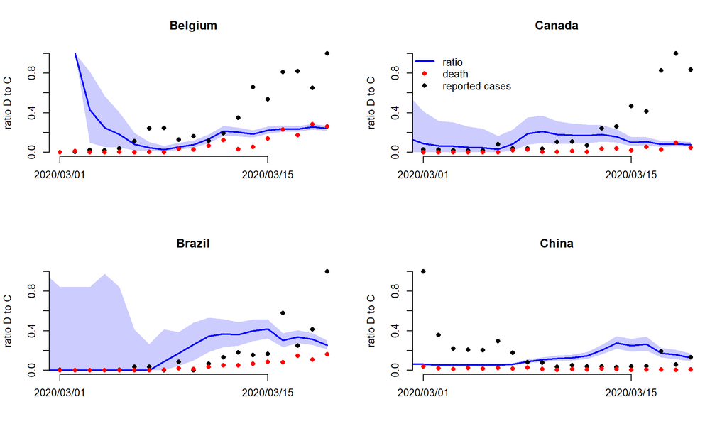

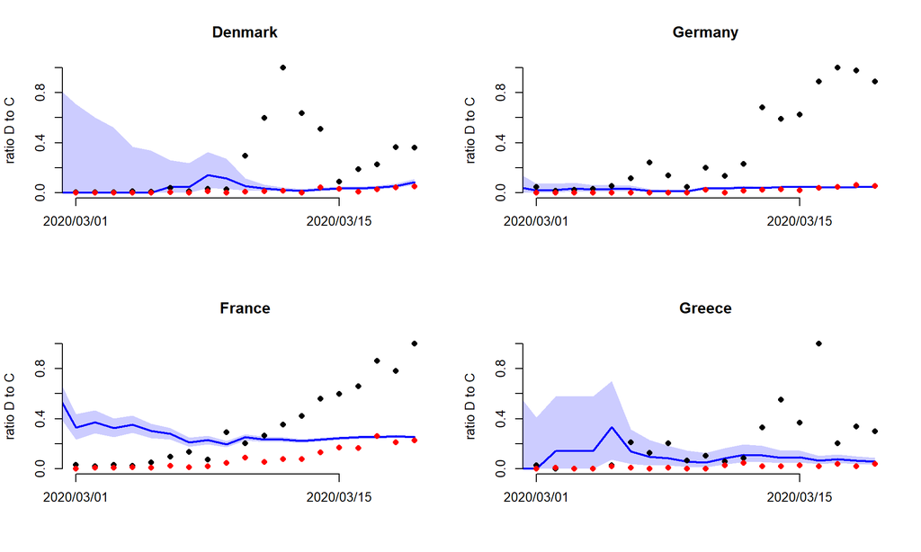

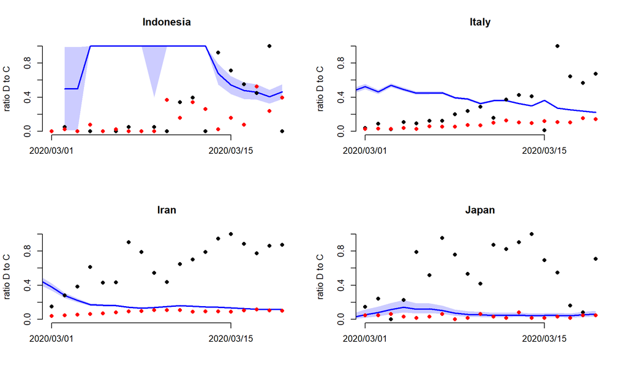

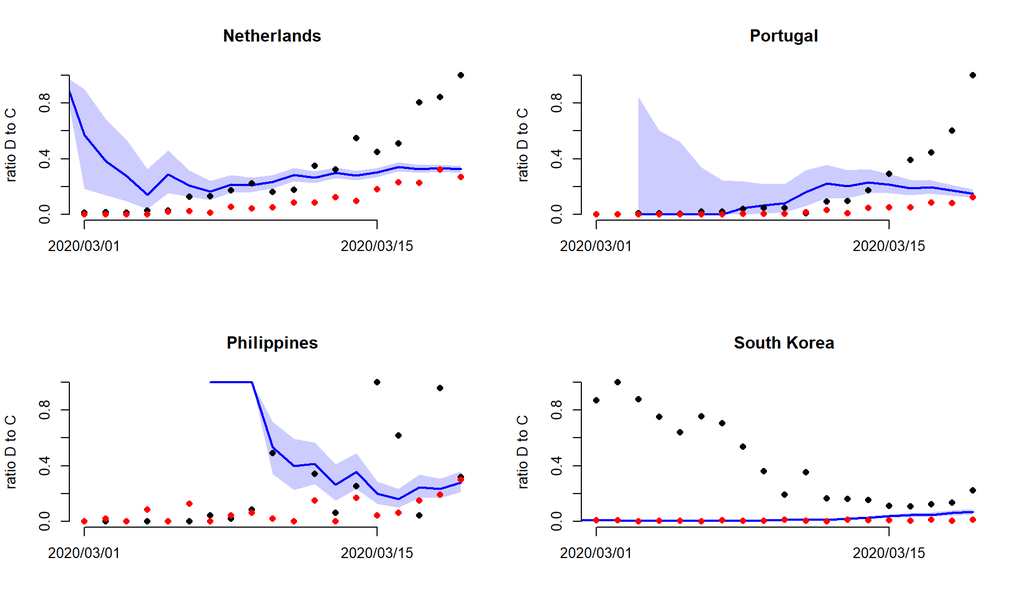

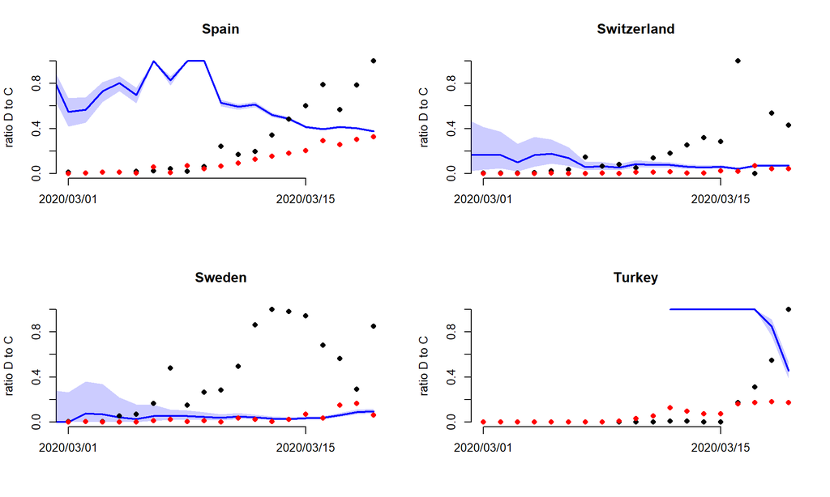

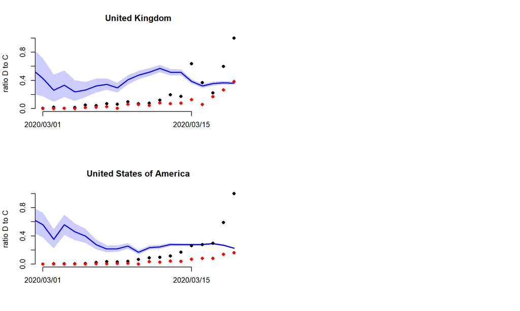

```r
f <- which(moving_DtoI[[1]]$date >= as.Date(c('01/03/2020'),format = '%d/%m/%Y'))

layout(matrix(1:4,2,2))
for (i in 1:N_geo){
  a <- moving_DtoI[[i]]
  plot(a$date,a$ratio,lwd = 2,
       #ylim = c(0,max(a[f,2:4],na.rm=TRUE)),
       ylim=c(0,1),
       type='l',
       xlim = c(as.Date(c('01/03/2020'),format = '%d/%m/%Y'),
                date_week_finishing-delay_report_death),
       bty ='n',
       main = snakecase::to_any_case(country[i], case = "title"),
       col = rgb(0,0,1),
       xlab = '', ylab = 'ratio D to C',
       xaxt="n")
  axis(1, at=as.Date(c('2020/03/01','2020/03/15'),format = '%Y/%m/%d'),labels = c('2020/03/01','2020/03/15'),las=1)

  polygon(c(a$date,rev(a$date)),
          c(a$lower,rev(a$upper)),
          border = NA,
          col = rgb(0,0,1,0.2))
  f2 <- which( I$dates %in% a$date)

  f2<-f2[f]
  inc <- cbind(I[f2,i+1],D[f2+delay_report_death,i+1])
  lines(a$date[f],
        inc[,1]/max(c(inc[,1],inc[,2])),
        type = 'p', pch=16,col='black')

  lines(a$date[f],
        inc[,2]/max(c(inc[,1],inc[,2])),
        type = 'p', pch=16,col='red')

  if(country[i] == "Canada"){
  legend('topleft',legend = c('ratio','death','reported cases'),bty='n',
         lwd=c(3,NA,NA),pch=c(NA,16,16),col = c(rgb(0,0,1),rgb(1,0,0),rgb(0,0,0)))
  }
}
```

Average and 95%CI for ratio of deaths to reported cases for the last 14 days.

If all cases (incl. asymptomatics) and death were reported, and the delay from reporting was exactly 10 days, then the ratio defined would be equivalent to the CFR.

```r
limits <- seq(date_week_finishing-13,date_week_finishing,by = 1)
f <- which(D$dates %in% limits)
temp <- binconf(x = colSums(D[f,-1]) , n = colSums(I[f-delay_report_death,-1]),alpha = .05, method = 'exact')


# assumed CFR
CFR <- .01
rho <- 1/temp*CFR
rho[rho>1] <- 1

# meaning the real epidemics is x times bigger than observed
multi_real <- 1/rho

# summary
summary_14days <- data.frame(
    country = country,
    deaths_to_reported_ratio = glue::glue(
        "{scales::percent(temp[,1], accuracy = 0.1)} ({scales::percent(temp[,2],accuracy = 0.1)} - {scales::percent(temp[,3],accuracy = 0.1)})",
    ),
    estimated_reporting = glue::glue(
        "{scales::percent(rho[,1], accuracy = 0.1)} ({scales::percent(rho[,2],accuracy = 0.1)} - {scales::percent(rho[,3],accuracy = 0.1)})",
    ),
    factor_to_real_size = glue::glue(
        "{round(multi_real[,1], 2)} ({round(multi_real[,2], 2)} - {round(multi_real[,3], 2)})",
    ),
    Observed_case_last_week = colSums(tail(I[,-1],7)),
    Predicted_True_case_last_week = glue::glue(
        "{prettyNum(signif(multi_real[,1] * colSums(tail(I[,-1],7)),digits = 2), big.mark = ",")} ",
        "({prettyNum(signif(multi_real[,2]*colSums(tail(I[,-1],7)),digits = 2), big.mark = ",")}",
        " - {prettyNum(signif(multi_real[,3]*colSums(tail(I[,-1],7)),digits = 2), big.mark = ",")})"
        )
  )
summary_14days <- summary_14days[order(temp[,1],decreasing = TRUE),]

write.csv(summary_14days,file = paste0('summary_DeathToRepoted_14days_',date_week_finishing,'.csv'))
```

```r
## unformatted
unformatted_summary_14days <- data.frame(
    country = country,
    deaths_to_reported_ratio_50 = round(temp[,1],digits = 3),
    deaths_to_reported_ratio_025 = round(temp[,2],digits = 3),
    deaths_to_reported_ratio_975 = round(temp[,3],digits = 3),
    estimated_reporting_50 = round(rho[,1],digits = 3),
    estimated_reporting_975 = round(rho[,2],digits = 3),
    estimated_reporting_025 = round(rho[,3],digits = 3),
    factor_to_real_size_50 = round(multi_real[,1],digits = 1),
    factor_to_real_size_025 = round(multi_real[,2],digits = 1),
    factor_to_real_size_975 = round(multi_real[,3],digits = 1),
    Observed_case_last_week = colSums(tail(I[,-1],7)),
    Predicted_True_case_last_week_50 = round(multi_real[,1]*colSums(tail(I[,-1],7)),digits = 0),
    Predicted_True_case_last_week_025 = round(multi_real[,2]*colSums(tail(I[,-1],7)),digits = 0),
    Predicted_True_case_last_week_975 = round(multi_real[,3]*colSums(tail(I[,-1],7)),digits = 0)
)
readr::write_csv(
    x = unformatted_summary_14days,
    path = paste0('unformatted_summary_DeathToRepoted_14days_',date_week_finishing,'.csv')
)
```

full size of epidemic so far

```r
# count cumulative death up to now I_true = D/CFR

colSums(D[,-1])/CFR

# for the 10 days up to now, deaths not observed, so I_rep last 10 days * colSums(tail(I[,-1],7))
True_size <- colSums(tail(I[,-1],10))*multi_real

Epidemic_size <- data.frame(country = as.character(country),
                            based_on_death = colSums(D[,-1])/CFR,
                            True_size_last_10_days = paste0(round(True_size[,1],digits = 1),
                                                          ' ; 95%CI [',
                                                          round(True_size[,2],digits = 1),
                                                          ';',
                                                          round(True_size[,3],digits = 1),
                                                          ']'),
                            True_size_last_Total = paste0(round(colSums(D[,-1])/CFR+True_size[,1],digits = 1),
                                                          ' ; 95%CI [',
                                                          round(colSums(D[,-1])/CFR+True_size[,2],digits = 1),
                                                          ';',
                                                          round(colSums(D[,-1])/CFR+True_size[,3],digits = 1),
                                                          ']'))

pop_size <- read.csv(file='API_SP.POP.TOTL_DS2_en_csv_v2_866861.csv',stringsAsFactors = FALSE)

pop_size$Country.Name <- as.character(pop_size$Country.Name)#clean
n_country <- 1:length(Epidemic_size$country)
#miss-spelled
Epidemic_size$country[-which(as.character(Epidemic_size$country) %in% as.character(pop_size$Country.Name))]
#corrections
pop_size$Country.Name[which(pop_size$Country.Name %in% 'Egypt, Arab Rep.')] <- 'Egypt'
pop_size$Country.Name[which(pop_size$Country.Name %in% 'Iran, Islamic Rep.')] <- 'Iran'
pop_size$Country.Name[which(pop_size$Country.Name %in% 'San Marino')] <- 'San_Marino'
pop_size$Country.Name[which(pop_size$Country.Name %in% 'Korea, Rep.')] <- 'South_Korea'
pop_size$Country.Name[which(pop_size$Country.Name %in% 'United Kingdom')] <- 'United_Kingdom'
pop_size$Country.Name[which(pop_size$Country.Name %in% 'United States')] <- 'United_States_of_America'
# check
Epidemic_size$country[-which(Epidemic_size$country %in% pop_size$Country.Name)]

f <- rep(NA,length(country))
for (i in 1:length(country)){
         f[i] <- which(as.character(pop_size$Country.Name) %in% as.character(Epidemic_size$country)[i])
}
cbind(pop_size$Country.Name[f],as.character(Epidemic_size$country))

Epidemic_size$Attack_rate <- paste0(round((colSums(D[,-1])/CFR+True_size[,1])/pop_size$X2018[f]*100,digits = 1),
                                    ' ; 95%CI [',
                                    round((colSums(D[,-1])/CFR+True_size[,2])/pop_size$X2018[f]*100,digits = 1),
                                    ';',
                                    round((colSums(D[,-1])/CFR+True_size[,3])/pop_size$X2018[f]*100,digits = 1),
                                    ']')
```